# homework

Lin YuYing

2021-12-19

## Question

Use knitr to produce at least 3 examples (texts, figures,tables).

## Answer

1: Harmonic equations are the starting point and important part of partial differential equations. The purpose of this paper is to make a systematic analysis and summary of harmonic functions, and introduce the derivation and properties of harmonic functions.

2:

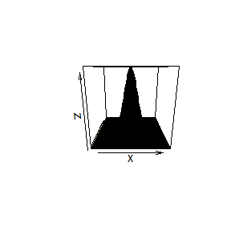

```r
binorm=function(x,y){
  mu1=0;mu2=0;sigma1=1;sigma2=1;rho=0
  cons=1/(2*pi*sigma1*sigma2*sqrt(1-rho^2))
  kuohao=((x-mu1)/sigma1)^2+
    2*rho*(x-mu1)/sigma1*(y-mu2)/sigma2+
    ((y-mu2)/sigma2)^2
  den=cons*exp(-1/(2*(1-rho^2))*kuohao)
  return(den)
}
x=y=seq(-5,5,by=0.1)
z=outer(x,y,binorm)
persp(x,y,z,col="green")
```

3:

```r
library(knitr)
df=data.frame(Name=c("Zhangzhu","Yishi","Wanwu","Zaoliu","Singqi"),
              Gender=c("F","M","F","M","F"),
              Age=c(21,22,23,21,25),
              Height=c(165,168,172,182,167),
              Weight=c(42.0,49.5,61.5,72.0,55.5))
kable(df)
```

| Name | Gender | Age | Height | Weight |
| --- | --- | --- | --- | --- |
| Zhangzhu | F | 21 | 165 | 42.0 |
| Yishi | M | 22 | 168 | 49.5 |
| Wanwu | F | 23 | 172 | 61.5 |
| Zaoliu | M | 21 | 182 | 72.0 |
| Singqi | F | 25 | 167 | 55.5 |

## Question

Exercises 3.4, 3.11, and 3.20 (pages 94-96, Statistical Computating with R).

## Answer

3.4:

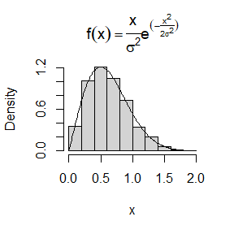

```r
n=1000
u=runif(n)
sigma=0.5
x=sqrt(-2*sigma^2*log(1-u))
hist(x, prob = TRUE,
     main = expression(f(x)==frac(x,sigma^2)*e^(-frac(x^2,2*sigma^2))))
y=seq(0, 2, .01)
lines(y, y*exp(-y^2/(2*sigma^2))/sigma^2)
```

3.11:

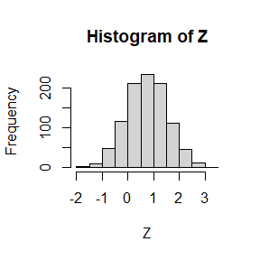

```r
n<-1000
X1<-rnorm(n,0,1)
X2<-rnorm(n,3,1)
Z<-0.75*X1+0.25*X2
hist(Z)
```

```r
r<-sample(seq(0.05,0.95,length.out=19),4,replace=FALSE)
r[1];r[2];r[3];r[4]
```

```
## [1] 0.45
```

```
## [1] 0.75
```

```
## [1] 0.95
```

```
## [1] 0.6
```

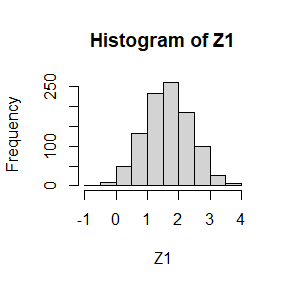

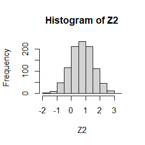

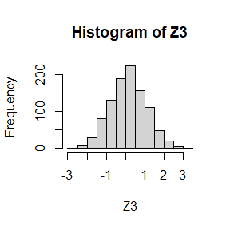

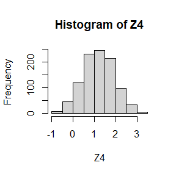

```r
Z1<-r[1]*X1+(1-r[1])*X2
Z2<-r[2]*X1+(1-r[2])*X2
Z3<-r[3]*X1+(1-r[3])*X2
Z4<-r[4]*X1+(1-r[4])*X2
hist(Z1);hist(Z2);hist(Z3);hist(Z4)
```

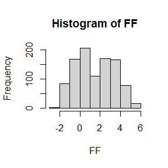

```r
D=sample(c(0,1),n,replace=TRUE)
FF=D*X1+(1-D)*X2
hist(FF)
```

```r
sum(D)/n
```

```
## [1] 0.518
```

3.20:

```r
set.seed(1234567)
n=1e4;beta=3;lambda=1;r=4;t=10
N_t=rpois(n, lambda*t)
X_t=length(n)
for (i in 1:n) {
  X_t[i]=sum(rgamma(N_t[i], r, beta))
}
mean(X_t)
```

```
## [1] 13.34436
```

```r
var(X_t)
```

```
## [1] 22.11849
```

## Question 5-4

Write a function to compute a Monte Carlo estimate of the Beta(3,3) cdf, and use the function to estimate F(x) for x = 0.1, 0.2,…, 0.9. Compare the estimates with the values returned by the pbeta function in R.

:

```r
x<-seq(0.1,0.9,length=9)
mm<-10000
u<-runif(mm)
ff<-numeric(length(x))
for (i in 1:length(x)) {
  g<-30*(x[i])^3*u^2*(1-u*x[i])^2
  ff[i]<-mean(g)
}

zhi<-pbeta(x,3,3)
print(round(rbind(x,ff,zhi),3))
```

```
##      [,1]  [,2]  [,3]  [,4] [,5]  [,6]  [,7]  [,8]  [,9]
## x   0.100 0.200 0.300 0.400  0.5 0.600 0.700 0.800 0.900
## ff  0.009 0.058 0.163 0.317  0.5 0.683 0.837 0.943 0.993
## zhi 0.009 0.058 0.163 0.317  0.5 0.683 0.837 0.942 0.991
```

## Question 5-9

The Rayleigh density is
$$f(x) = \frac{x}{\sigma^2}e^{-x^2/(2\sigma^2)}, \quad x\ge 0, \sigma>0.$$
Implement a function to generate samples from a Rayleigh($\sigma$) distribution,using antithetic variables. What is the percent reduction in variance of$\frac{X+X^{'}}{2}$compared with$\frac{X_{1}+X_{2}}{2}$for independent$X_{1},X_{2}$?

:

```r
sigma=1
M<-function(x,R =10000,anti=TRUE){
  u<-runif(R/2,0,x)
  if (!anti) v<-runif(R/2) else v<-1-u
  u<-c(u,v)
  cdf<-numeric(length(x))
  for (i in 1:length(x)){
    g=u*(x[i]/sigma)^2*exp(-(u*x[i]/sigma)^2/2)
    cdf[i]<-mean(g)
  }
  cdf
}
m=1000
M1<-M2<-numeric(m)
x<-1
for (i in 1:m) {
  M1[i]=M(x,R=1000,anti=F)
  M2[i]=M(x,R=1000,anti=T)
}
v1=var(M1)
v2=var(M2)
rv=round(v2/v1,3)
rv
```

```
## [1] 0.107
```

## Question 5-13

Find two importance functions $f_1,f_2$ that are supported on $(1,\infty)$ and are ‘close’ to
$$g(x)=\frac{x^2}{\sqrt{2\pi}}e^{-x^2/2},x>1$$
Which of your two importance functions should produce the smaller variance in estimating
$$\int_1^\infty\frac{x^2}{\sqrt{2\pi}}e^{-x^2/2}dx$$
by importance sampling? Explain.

:
$$f_1=\frac{3}{2}e^{-x^2},f_2=2x$$

$$\int_1^\infty\frac{x^2}{\sqrt{2\pi}}e^{-x^2/2}dx=\int_0^1\frac{1}{t^4\sqrt{2\pi}}e^{-1/(2t^2)}dt$$

```r
k=10000
est<-sd<-numeric(2)
g<-function(x) {
  exp(-1/(2*x^2))/x^4/sqrt(2*pi)*(x>0)*(x<1)
}
x<-runif(k) #f1
pp1<-g(x)/(3*exp(-x^2)/2)
est[1]<-mean(pp1)
sd[1]<-sd(pp1)

x<-runif(k) #f2
pp2<-g(x)/(2*x)
est[2]<-mean(pp2)
sd[2]<-sd(pp2)

res<-rbind(est=round(est,4),sd=round(sd,4))
colnames(res)<-paste0('f',1:2)
res
```

```
##         f1     f2
## est 0.4058 0.3604
## sd  0.2850 0.3109
```

## Question 5-14

Obtain a Monte Carlo estimate of
$$\int_1^\infty\frac{x^2}{\sqrt{2\pi}}e^{-x^2/2}dx$$
by importance sampling.

:

```r
k=10000
g<-function(x) {
  exp(-1/(2*x^2))/x^4/sqrt(2*pi)*(x>0)*(x<1)
}
x<-runif(k) #f1
pf1<-g(x)/(3*exp(-x^2)/2)
gj<-mean(pf1)
gj
```

```
## [1] 0.4026316
```

## Question 6-5

Suppose a 95% symmetric t-interval is applied to estimate a mean, but the sample data are non-normal. Then the probability that the confidence interval covers the mean is not necessarily equal to 0.95. Use a Monte Carlo experiment to estimate the coverage probability of the t-interval for random samples of $\mathcal{X}^2(2)$ data with sample size n = 20. Compare your t-interval results with the simulation results in Example 6.4. (The t-interval should be more robust to departures from normality than the interval for variance.)

:
$$[\bar{x}-t_{1-\frac{\alpha}{2}}\frac{s}{\sqrt{n}},\bar{x}+t_{1-\frac{\alpha}{2}}\frac{s}{\sqrt{n}}]$$

```r
intval=function(x,alpha=0.05){
  n=length(x);df=n-1
  a=mean(x)-qt(1-alpha/2,df)*sd(x)/sqrt(n)
  b=mean(x)+qt(1-alpha/2,df)*sd(x)/sqrt(n)
  data.frame(a=a,b=b)
}
m=20
left=numeric(m);right=numeric(m)
set.seed(12333)
for(i in 1:m){
  x=rchisq(m,df=2)
  estimate=intval(x)
  left[i]=estimate$a
  right[i]=estimate$b
}
sum(left<2&right>2);mean(left<2&right>2)
```

```
## [1] 20
```

```
## [1] 1
```

## Question 6-A

Use Monte Carlo simulation to investigate whether the empirical Type I error rate of the t-test is approximately equal to the nominal significance level $\alpha$, when the sampled population is non-normal. The t-test is robust to mild departures from normality. Discuss the simulation results for the cases where the sampled population is (i) $\mathcal{X}^2(1)$ , (ii) Uniform(0,2), and (iii) Exponential(rate=1). In each case, test $H_0:\mu=\mu_0 vs H_0:\mu\not=\mu_0$ , where $\mu_0$ is the mean of $\mathcal{X}^2(1)$ , Uniform(0,2), and Exponential(1), respectively.

:

```r
#1
n<-20
alpha<-0.05
m<-10000
kk1<-numeric(m)
for (j in 1:m){
  x<-rchisq(n,df=1)
  t_test<-t.test(x,mu=1)
  kk1[j]<-t_test$p.value
}
pp1<-mean(kk1<alpha)
se1<-sqrt(pp1*(1-pp1)/m)
print(c(pp1,se1))
```

```
## [1] 0.108800000 0.003113881
```

```r
#2
kk2<-numeric(m)
for (j in 1:m){
  x<-runif(n,0,2)
  t_test<-t.test(x,mu=1)
  kk2[j]<-t_test$p.value
}
pp2<-mean(kk2<alpha)
se2<-sqrt(pp2*(1-pp2)/m)
print(c(pp2,se2))
```

```
## [1] 0.049500000 0.002169095
```

```r
#3
kk3<-numeric(m)
for (j in 1:m){
  x<-rexp(n,1)
  t_test<-t.test(x,mu=1)
  kk3[j]<-t_test$p.value
}
pp3<-mean(kk3<alpha)
se3<-sqrt(pp3*(1-pp3)/m)
print(c(pp3,se3))
```

```
## [1] 0.085100000 0.002790304
```

## Exercise 6.C

Repeat Examples 6.8 and 6.10 for Mardia鈥檚 multivariate skewness test. Mardia proposed tests of multivariate normality based on multivariate generalizations of skewness and kurtosis. If X and Y are iid, the multivariate population skewness $\beta_{1,d}$ is defined by Mardia as
$$\beta_{1,d}=E[(X-\mu)^T {\Sigma}^{-1}(X-\mu)]^3$$
Under normality, $\beta_{1,d}=0$. The multivariate skewness statistic is
$$b_{1,d}=\frac{1}{n^2}\sum\limits_{i,j=1}^n((X_i-\bar{X})^T \widehat{\Sigma}^{-1}(X_j-\bar{X}))^3$$
where $\widehat{\Sigma}$ is the maximum likelihood estimator of covariance. Large values of $b_{1,d}$ are significant. The asymptotic distribution of $nb_{1,d}/6$ is chisquared with d(d + 1)(d + 2)/6 degrees of freedom.

**Solution.**

```r
library(MASS)
SSig<-matrix(c(1,0,0,1),2,2)
n<-c(10, 20, 30, 50)
d=2
alpha=0.1

sk=function(n){
  for(i in 1:n){
    for(j in 1:n){
      x=mvrnorm(n, rep(0,2), SSig)
      x_bar=mean(x)
      cc=cov(x)
      bb[i,j]=(t(x[i,]-x_bar)%*%solve(cc)%*%(x[j,]-x_bar))^3
    }
  }
  bk=sum(bb)/((n)^2)
  return(bk)
}

bijie<-qchisq(1-alpha/2,df= d*(d+1)*(d+2)/6)
bijie
```

```
## [1] 9.487729
```

```r
pow_re<-numeric(4)
m <- 100
for (i in 1:length(n)) {
  sket<- numeric(m)
  bb=matrix(0,n[i],n[i])
  for (j in 1:m) {
    sket[j] <- as.integer(n[i]*sk(n[i])/6>=bijie)
  }
  pow_re[i] <- mean(sket)
}

result <- rbind(n, pow_re)
colnames(result)=c("n1", "n2","n3", "n4")
rownames(result)=c("n","p.reject")
result
```

```
##             n1   n2    n3   n4
## n        10.00 20.0 30.00 50.0
## p.reject  0.14  0.1  0.13  0.2
```

## Exercise 7.7

Refer to Exercise 7.6. Efron and Tibshirani discuss the following example. The five-dimensional scores data have a covariance matrix $\Sigma$, with positive eigenvalues $\lambda_1>\cdots>\lambda_5$. In principal components analysis,
$$\theta=\frac{\lambda_1}{\sum_{i=1}^5\lambda_i}$$
measures the proportion of variance explained by the first principal component. Let $\hat\lambda_1>\cdots>\hat\lambda_5$ be the eigenvalues of $\hat\Sigma$, where $\hat\Sigma$ is the MLE of $\Sigma$. Compute the sample estimate
$$\hat\theta=\frac{\hat\lambda_1}{\sum_{i=1}^5\hat\lambda_i}$$
of $\theta$. Use bootstrap to estimate the bias and standard error of $\hat\theta$.

**Solution.**

```r
set.seed(0)
library(boot)
library(bootstrap)
n=nrow(scor)
sgm.h=(n-1)/n*cov(scor)
lab_h=eigen(sgm.h)$values
the_h=max(lab_h)/sum(lab_h)

ad=function(dat,i){
  x=dat[i,]
  n=nrow(scor)
  lab=eigen((n-1)/n*cov(x))$values
  the=max(lab)/sum(lab)
  return(the)
}
bst_res=boot(
  data=cbind(scor$mec,scor$vec,scor$alg,scor$ana,scor$sta),
  statistic=ad,R=2000)
the_b=bst_res$t
bias_b=mean(the_b)-the_h
se_b=sqrt(var(the_b))

the_h
```

```
## [1] 0.619115
```

```r
bias_b
```

```
## [1] 0.001631945
```

```r
se_b
```

```
##            [,1]
## [1,] 0.04708343
```

the sample estimate of $\theta$ is 0.619; the bias of $\hat\theta$ is 0.001631945; the standard error of $\hat\theta$ is 0.04708343.

## Exercise 7.8

Refer to Exercise 7.7. Obtain the jackknife estimates of bias and standard error of $\hat\theta$.

**Solution.**

```r
the_j=rep(0,n)
for(i in 1:n){
  x=scor[-i,]
  lam=eigen((n-1)/n*cov(x))$values
  the_j[i]=max(lam)/sum(lam)
}
bias_j=(n-1)*(mean(the_j)-the_h)
se_j=(n-1)*sqrt(var(the_j)/n)

bias_j
```

```
## [1] 0.001069139
```

```r
se_j
```

```
## [1] 0.04955231
```

the jackknife estimate of bias of $\hat\theta$ is 0.001069139; the jackknife estimate of standard error of $\hat\theta$ is 0.04955231.

## Exercise 7.9

Refer to Exercise 7.7. Compute 95% percentile and BCa confidence intervals for $\hat\theta$.

**Solution.**

```r
boot.ci(bst_res,conf=0.95,type=c('perc','bca'))
```

```
## BOOTSTRAP CONFIDENCE INTERVAL CALCULATIONS
## Based on 2000 bootstrap replicates
##
## CALL :
## boot.ci(boot.out = bst_res, conf = 0.95, type = c("perc", "bca"))
##
## Intervals :
## Level     Percentile            BCa
## 95%   ( 0.5224,  0.7076 )   ( 0.5221,  0.7067 )
## Calculations and Intervals on Original Scale
```

95% percentile confidence intervals for $\hat\theta$ are (0.5224,0.7076); 95% BCa confidence intervals for $\hat\theta$ are (0.5221,0.7067).

## Exercise 7.B

Repeat Project 7.A for the sample skewness statistic. Compare the coverage rates for normal populations (skewness 0) and $\chi^{2}(5)$ distributions (positive skewness)

**Solution.**

```r
set.seed(0)
library(boot)
n=1000
ksn=function(dat,i){
  m3=mean((dat[i]-mean(dat[i]))^3)
  m2=mean((dat[i]-mean(dat[i]))^2)
  return(m3/m2^1.5)
}

da1=rnorm(n,0,1)
b1=boot(data=da1,statistic=ksn,R=2000)
print(b1)
```

```
##
## ORDINARY NONPARAMETRIC BOOTSTRAP
##
##
## Call:
## boot(data = da1, statistic = ksn, R = 2000)
##
##
## Bootstrap Statistics :
##      original       bias    std. error
## t1* 0.0918628 -0.001161863  0.07302801
```

```r
ci1=boot.ci(b1,type=c("basic","norm","perc"))
print(ci1)
```

```
## BOOTSTRAP CONFIDENCE INTERVAL CALCULATIONS
## Based on 2000 bootstrap replicates
##
## CALL :
## boot.ci(boot.out = b1, type = c("basic", "norm", "perc"))
##
## Intervals :
## Level      Normal              Basic              Percentile
## 95%   (-0.0501,  0.2362 )   (-0.0484,  0.2339 )   (-0.0501,  0.2321 )
## Calculations and Intervals on Original Scale
```

```r
sum(ci1$normal[2]<b1$t&ci1$normal[3]>b1$t)
```

```
## [1] 1905
```

```r
mean(ci1$normal[2]<b1$t&ci1$normal[3]>b1$t)
```

```
## [1] 0.9525
```

```r
da2=rchisq(n,df=5)
b2=boot(data=da2,statistic=ksn,R=2000)
print(b2)
```

```
##
## ORDINARY NONPARAMETRIC BOOTSTRAP
##
##
## Call:
## boot(data = da2, statistic = ksn, R = 2000)
##
##
## Bootstrap Statistics :
##     original     bias    std. error
## t1* 1.216796 -0.0055505  0.09265988
```

```r
ci2=boot.ci(b2,type = c("basic","norm","perc"))
print(ci2)
```

```
## BOOTSTRAP CONFIDENCE INTERVAL CALCULATIONS
## Based on 2000 bootstrap replicates
##
## CALL :
## boot.ci(boot.out = b2, type = c("basic", "norm", "perc"))
##
## Intervals :
## Level      Normal              Basic              Percentile
## 95%   ( 1.041,  1.404 )   ( 1.035,  1.400 )   ( 1.033,  1.399 )
## Calculations and Intervals on Original Scale
```

```r
sum(ci2$normal[2]<b2$t&ci2$normal[3]>b2$t)
```

```
## [1] 1896
```

```r
mean(ci2$normal[2]<b2$t&ci2$normal[3]>b2$t)
```

```
## [1] 0.948
```

```r
set.seed(123456)
R<-999
l<-1:2000
x=rnorm(1000,0,1)
y=runif(1000,3,5)
z<-c(x,y)
n<-length(x)
rs<-numeric(R);t0<-cor.test(x,y,method="spearman")
for (i in 1:R) {
  ll=sample(l,size=n,replace=FALSE)
  x1=z[ll];y1=z[-ll]
  rs[i]=cor(x1,y1,method="spearman")
}
p=mean(abs(rs)>=abs(t0$estimate))
round(c(p,t0$p.value),3)
```

```
## [1] 0.175 0.166
```

the achieved significance level of the permutation test is 0.175;the p-value reported by cor.test is 0.166;this means cor.test is better.

## Exercise

Design experiments for evaluating the performance of the NN,energy, and ball methods in various situations. (1)Unequal variances and equal expectations (2)Unequal variances and unequal expectations (3)Non-normal distributions: t distribution with 1 df (heavy-tailed distribution), bimodel distribution (mixture of two normal distributions) (4)Unbalanced samples (say, 1 case versus 10 controls)

**Solution.**

(1)Unequal variances and equal expectations

```r
library(RANN)
library(boot)
library(energy)
library(Ball)
alpha<-0.1;k<-3;R<-99;set.seed(12345)
n1<-n2<-5;n<-n1+n2;N=c(n1,n2)
ddg<-function(z,da,sizes,k){
  if(is.vector(z)) z<-data.frame(z,0);
  z<-z[da,];
  NN<-nn2(data=z,k=k+1)
  b1<-NN$nn.idx[1:n1,-1]
  b2<-NN$nn.idx[(n1+1):n,-1]
  i1<-sum(b1<n1+0.5);i2<-sum(b2>n1+0.5)
  (i1+i2)/(k*n)
}
nnq<-function(z,sizes,k){
  bh<-boot(data=z,statistic=ddg,R=R,
           sim="permutation",sizes=sizes,k=3)
  ts<-c(bh$t0,bh$t)
  kkp<-mean(ts>=ts[1])
  list(statistic=ts[1],p.value=kkp)
}
pv1<-matrix(NA,100,3)
for(i in 1:100){
  x=rnorm(5,1,1)
  y=runif(5,0,2)
  z<-c(x,y)
  pv1[i,1]<-nnq(z,N,k)$p.value
  pv1[i,2]<-eqdist.etest(z,sizes=c(n1,n2),R=R)$p.value
  pv1[i,3]<-bd.test(x=x,y=y,num.permutations=99)$p.value
}
pow1<-colMeans(pv1<alpha)
pow1
```

```
## [1] 0.04 0.09 0.09
```

(2)Unequal variances and unequal expectations

```r
n1<-n2<-5;n<-n1+n2;N=c(n1,n2)
pv2<-matrix(NA,100,3)
for(i in 1:100){
  x=rnorm(5,1,1.5)
  y=runif(5,0,3.5)
  z<-c(x,y)
  pv2[i,1]<-nnq(z,N,k)$p.value
  pv2[i,2]<-eqdist.etest(z,sizes=N,R=R)$p.value
  pv2[i,3]<-bd.test(x=x,y=y,num.permutations=99)$p.value
}
pow2<-colMeans(pv2<alpha)
pow2
```

```
## [1] 0.12 0.26 0.19
```

Energy could be more powerful for unequal variances and unequal expectations.

(3)Non-normal distributions

```r
pv3<-matrix(NA,100,3)
for(i in 1:100){
  x=rt(5,df=1)
  y=c(rnorm(2,0,1),rnorm(3,0,1.5))
  z<-c(x,y)
  pv3[i,1]<-nnq(z,N,k)$p.value
  pv3[i,2]<-eqdist.etest(z,sizes=c(n1,n2),R=R)$p.value
  pv3[i,3]<-bd.test(x=x,y=y,num.permutations=99)$p.value
}
pow3<-colMeans(pv3<alpha)
pow3
```

```
## [1] 0.16 0.15 0.15
```

(4)Unbalanced samples

```r
n1<-4;n2<-5;n<-n1+n2;N=c(n1,n2)
pv4<-matrix(NA,100,3)
for(i in 1:100){
  x=rnorm(4,0,1)
  y=c(rnorm(2),rnorm(3,0,2))
  z<-c(x,y)
  pv4[i,1]<-nnq(z,N,k)$p.value
  pv4[i,2]<-eqdist.etest(z,sizes=c(n1,n2),R=R)$p.value
  pv4[i,3]<-bd.test(x=x,y=y,num.permutations=99)$p.value
}
pow4<-colMeans(pv4<alpha)
pow4#
```

```
## [1] 0.08 0.07 0.08
```

## Exercise 9.3

Use the Metropolis-Hastings sampler to generate random variables from a standard Cauchy distribution. Discard the first 1000 of the chain, and compare the deciles of the generated observations with the deciles of the standard Cauchy distribution (see qcauchy or qt with df=1). Recall that a Cauchy$(\theta, \eta)$distribution has density function
$$f(x)=\frac{1}{\theta\pi(1+[(x-\eta)/\theta]^2)},\quad-\infty<x<\infty,\theta>0$$
The standard Cauchy has the Cauchy$(\theta=1, \eta=0)$ density. (Note that the standard Cauchy density is equal to the Student t density with one degree of freedom.)

**Solution.**

For the proposal distribution, try the Student t distribution.

```r
set.seed(12345)
f=function(x,theta,eta){
  if (any(theta<0)) return(0)
  return(1/(theta*pi*(1+((x-eta)/theta)^2)))
}

m=4000
x=numeric(m)
x[1]=rt(1,df=1)
k=0
u=runif(m)

for (i in 2:m){
  xt=x[i-1]
  y=rt(1,df=abs(xt))
  hh=f(y,1,0)*dt(xt,df=abs(y))
  dd=f(xt,1,0)*dt(y,df=abs(xt))
  if (u[i]<=abs(hh/dd)){
    x[i]=y
  }
  else{
    x[i]=xt
    k=k+1
  }
}
k
```

```
## [1] 1157
```

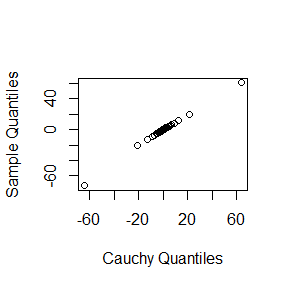

```r
y=x[1001:m]
a=ppoints(100)
we=tan(pi*(a-0.5))
ww=quantile(x,a)
qqplot(we,ww, main="",xlab="Cauchy Quantiles",
       ylab="Sample Quantiles")
```

```r
h<-seq(0.1,0.9,length=9)
Q=quantile(y,h)
Q
```

```
##         10%         20%         30%         40%         50%         60%
## -3.29622734 -1.41695518 -0.74054703 -0.37572983 -0.02445973  0.33093612
##         70%         80%         90%
##  0.74885173  1.35799918  3.03065323
```

```r
zhen=qt(h,df=1)
summ=round(rbind(Q,zhen),3)
rownames(summ)=c("MH","qt")
knitr::kable(summ)
```

|  | 10% | 20% | 30% | 40% | 50% | 60% | 70% | 80% | 90% |
| --- | --- | --- | --- | --- | --- | --- | --- | --- | --- |
| MH | -3.296 | -1.417 | -0.741 | -0.376 | -0.024 | 0.331 | 0.749 | 1.358 | 3.031 |
| qt | -3.078 | -1.376 | -0.727 | -0.325 | 0.000 | 0.325 | 0.727 | 1.376 | 3.078 |

**Solution.**

```r
N=15000
XY=matrix(0,N,2)
a=2
b=1
n=10
XY[1,]=c(2,0.5)
for (i in 2:N){
  yy<-XY[i-1,2]
  XY[i,1]<-rbinom(1,n,yy)
  xx<-XY[i,1]
  XY[i,2]<-rbeta(1,xx+a,n-xx+b)
}
x<-XY[1001:N,]

colMeans(x)
```

```
## [1] 6.6328571 0.6651245
```

```r
cov(x)
```

```
##           [,1]       [,2]
## [1,] 7.1387160 0.54978626
## [2,] 0.5497863 0.05502689
```

```r
cor(x)
```

```
##           [,1]      [,2]
## [1,] 1.0000000 0.8771954
## [2,] 0.8771954 1.0000000
```

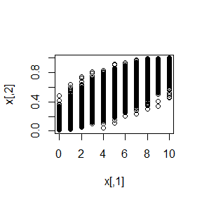

```r
plot(x)
```

The sample means, variances, and correlation are close to the true parameters.

## Exercise

For each of the above exercise, use the Gelman-Rubin method to monitor convergence of the chain, and run the chain until it converges approximately to the target distribution according to $\hat{R}<1.2$.

**Solution.** ##9.3

```r
set.seed(12345)
GR=function(psi){
  psi=as.matrix(psi)
  n=ncol(psi)
  k=nrow(psi)
  psi.means=rowMeans(psi)
  B=n*var(psi.means)
  psi.w=apply(psi,1,"var")
  W=mean(psi.w)
  v=W*(n-1)/n+(B/n)
  r=v/W
  return(r)
}
cc=function(N,X1){
  x=numeric(N)
  x[1]=X1
  u=runif(N)
  for (i in 2:N){
    xt=x[i-1]
    y=rt(1,df=abs(xt))
    num=f(y,1,0)*dt(xt,df=abs(y))
    den=f(xt,1,0)*dt(y,df=abs(xt))
    if (u[i]<=abs(num/den)){
      x[i]=y
    } else{
      x[i]=xt
    }
    return(x)
  }
}
n=500
b=100
x0=c(-2,-1,1,2)
X=matrix(0,nrow=4,ncol=n)
for (i in 1:4)
  X[i,]=cc(n,x0[i])
psi=t(apply(X,1,cumsum))
for (i in 1:nrow(psi))
  psi[i,]=psi[i,]/(1:ncol(psi))
print(GR(psi))
```

```
## [1] 1.116357
```

##9.8

```r
set.seed(12345)
N=5000
XY=matrix(0,N,2)
a=2;b=1;n=100
jc=function(XY,N){
  for (i in 2:N){
    yy<-XY[i-1,2]
    XY[i,1]<-rbinom(1,n,yy)
    xx<-XY[i,1]
    XY[i,2]<-rbeta(1,xx+a,n-xx+b)
  }
  return(XY)
}
psi=t(apply(jc(XY,N), 1, cumsum))
for (i in 1:nrow(psi))
  psi[i,]=psi[i,]/(1:ncol(psi))
print(GR(psi))
```

```
## [1] 1.181764
```

the chain has approximately converged to the target distribution within approximately 5000 iterations ($\hat{R}=1.18$).

## Exercise 11.3

1. Write a function to compute the kth term in
   $$\sum_{k=0}^{\infty}\frac{(-1)^k}{k!2^k}
   \frac{{\Vert a \Vert}^{2k+2}}{(2k+1)(2k+3)}
   \frac{\Gamma(\frac{d+1}{2})\Gamma(k+\frac{3}{2})}{\Gamma(k+\frac{d}{2}+1)}$$
   where $d\ge1$ is an integer, a is a vector in ${\mathbb{R}}^d$, and $\Vert\cdot\Vert$ denotes the Euclidean norm. Perform the arithmetic so that the coefficients can be computed for (almost) arbitrarily large k and d. (This sum converges for all ${a\in\mathbb{R}}^d$).
2. Modify the function so that it computes and returns the sum.
3. Evaluate the sum when $a=(1,2)^T$.

**Solution.**

```r
f=function(k,a){
  d=nrow(a)
  l1=(-1/2)^k/factorial(k)
  l2=(norm(a,type="F"))^(2*k+2)/(2*k+1)/(2*k+2)
  l3=exp(lgamma((d+2)/2)+lgamma(k+1.5)-lgamma(k+d/2+1))
  l=l1*l2*l3
  return(l)
}
ss=numeric(length=0)
sumf=function(a){
ss[1]=f(1,a)
i=2
repeat{
  ss[i]=f(i,a)
  if(abs(ss[i]-ss[i-1])<=1e-6) break
  else i=i+1
}
su=sum(ss)
return(su)
}
a=matrix(c(1,2),ncol=1)
round(sumf(a),3)
```

```
## [1] -0.487
```

the sum is -0.487 when $a=(1,2)^T$

## Exercise 1

Why are the following two invocations of lapply() equivalent? trims <- c(0, 0.1, 0.2, 0.5) x <- rcauchy(100) lapply(trims, function(trim) mean(x, trim = trim)) lapply(trims, mean, x = x)

**Solution.**

The first lapply function is to find the truncated mean of a random variable that obeys the Cauchy distribution;the second lapply function is to truncate the mean of a random variable that obeys the Cauchy distribution.Both lapply functions are truncated means of 0,0.1,0.2,0.5 for random variables that obeys the Cauchy distribution.

## Exercise 5

For each model in the previous two exercises, extract $R^2$ using the function below. rsq <- function(mod) summary(mod)$r.squared

**Solution.**

```r
rsq=function(mod) summary(mod)$r.squared
##exercise 3
formulas=list(
  mpg~disp,
  mpg~I(1/disp),
  mpg~disp+wt,
  mpg~I(1/disp)+wt
)
kk3=lapply(1:4,function(i) {lm(formulas[[i]],data=mtcars)})
rt3=matrix(0,4,2)
dimnames(rt3)[[2]]=c("i","r.squared")
for(i in 1:4){
  rt3[i,1]=i
  rt3[i,2]=rsq(kk3[[i]])
}
rt3
```

```
##      i r.squared
## [1,] 1 0.7183433
## [2,] 2 0.8596865
## [3,] 3 0.7809306
## [4,] 4 0.8838038
```

```r
##exercise 4
bootstraps=lapply(1:10, function(i) {
  rows=sample(1:nrow(mtcars), rep = TRUE)
  mtcars[rows, ]
})
kk4=lapply(1:10,function(i) {lm(mpg~disp,data=bootstraps[[i]])})
rt4=matrix(0,10,2)
dimnames(rt4)[[2]]=c("i","r.squared")
for(i in 1:10){
  rt4[i,1]=i
  rt4[i,2]=rsq(kk4[[i]])
}
rt4
```

```
##        i r.squared
##  [1,]  1 0.7474860
##  [2,]  2 0.6190004
##  [3,]  3 0.6565692
##  [4,]  4 0.6157443
##  [5,]  5 0.6635869
##  [6,]  6 0.6519588
##  [7,]  7 0.6785896
##  [8,]  8 0.7278543
##  [9,]  9 0.7164619
## [10,] 10 0.7072970
```

## Exercise 1

Use vapply() to: a) Compute the standard deviation of every column in a numeric data frame. b) Compute the standard deviation of every numeric column in a mixed data frame. (Hint: you ’ll need to use vapply() twice.)

**Solution.**

```r
h1=rnorm(50,1,2)
h2=rt(50,df=3)
hu1=data.frame(h1,h2)
vapply(hu1,sd,numeric(1))
```

```
##       h1       h2
## 2.452561 1.704149
```

```r
h12=c(h1,h2)
h3=rchisq(100,df=2)
hu2=data.frame(h12,h3)
vapply(hu2,sd,numeric(1))
```

```
##      h12       h3
## 2.144875 1.838895
```

## Exercise 7

Implement mcsapply(), a multicore version of sapply(). Can you implement mcvapply(), a parallel version of vapply()? Why or why not?

**Solution.**

```r
mcvapply=function(X,fun,simplify=T){
  answer=lapply(X=as.list(X),FUN=fun)
  if (is.character(X)&&is.null(names(answer)))
    names(answer)=X
  if (!isFALSE(simplify))
    simplify2array(answer,higher=(simplify=="array"))
  else answer
}
mcvapply(mtcars,mean)
```

```
##        mpg        cyl       disp         hp       drat         wt       qsec
##  20.090625   6.187500 230.721875 146.687500   3.596563   3.217250  17.848750
##         vs         am       gear       carb
##   0.437500   0.406250   3.687500   2.812500
```

the mcvapply function is constructed as above

## Exercise 9.8

This example appears in [40]. Consider the bivariate density
$$f(x, y) \propto\left(\begin{array}{l} n \\ x \end{array}\right) y^{x+a-1}(1-y)^{n-x+b-1}, \quad x=0,1, \ldots, n, 0 \leq y \leq 1.$$
It can be shown that for fixed a, b, n, the conditional distributions are Binomial(n,y) and Beta(x+a,n-x+b). Use the Gibbs sampler to generate a chain with target joint density f(x, y).

Write an Rcpp function for Exercise 9.8 (page 278, Statistical Computing with R). Compare the corresponding generated random numbers with pure R language using the function “qqplot”. Campare the computation time of the two functions with the function “microbenchmark”. Comments your results

**Solution.**
$$(X|Y=y)\overset{d}= B(n,y),\quad (Y|X=x)\overset{d}= Beta(x+a,n-x+b)$$

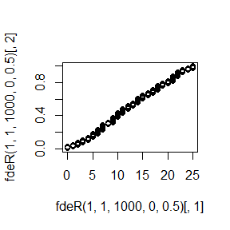

```r
library(Rcpp)
library(microbenchmark)
cppFunction('NumericMatrix fdeC(int a,int b,int N,int x,int y){
  NumericMatrix GX(N,2);
  double X0,X1;
  GX(0,0)=x;GX(0,1)=y;
  for(int i=1;i<N;i++){
  X1=GX(i-1,1);
  GX(i,0)=rbinom(1,25,X1)[0];
  X0=GX(i,0);
  GX(i,1)=rbeta(1,X0+a,25-X0+b)[0];
  }
  return(GX);
}')
fdeR=function(a,b,N,x,y){
  GX=matrix(0,N,2)
  GX[1,]=c(x,y)
  for(i in 2:N){
    X2=GX[i-1,2]
    GX[i,1]=rbinom(1,25,X2)
    X1=GX[i,1]
    GX[i,2]=rbeta(1,X1+a,25-X1+b)
  }
  return(GX)
}
qqplot(fdeR(1,1,1000,0,0.5)[,1],fdeR(1,1,1000,0,0.5)[,2])
```

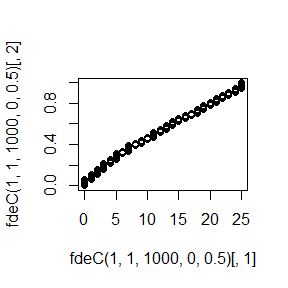

```r
qqplot(fdeC(1,1,1000,0,0.5)[,1],fdeC(1,1,1000,0,0.5)[,2])
```

```r
microbenchmark(fdeR=fdeR(1,1,1000,0,0.5),fdeC=fdeC(1,1,1000,0,0.5))
```

```
## Unit: microseconds
##  expr      min        lq      mean   median        uq       max neval
##  fdeR 4260.602 4595.3510 5877.2591 4874.601 5584.0505 20768.101   100
##  fdeC  409.801  420.0505  450.7009  427.201  433.3005   744.502   100
```

```r
ts=microbenchmark(fdeR=fdeR(1,1,1000,0,0.5),fdeC=fdeC(1,1,1000,0,0.5))
summary(ts)[,c(1,3,5,6)]
```

```
##   expr       lq   median        uq
## 1 fdeR 4745.051 5087.851 6120.8520
## 2 fdeC  424.551  433.651  493.3005
```

```r
microbenchmark(fdeR=fdeR(1,10,1000,0,0.5),fdeC=fdeC(1,10,1000,0,0.5))
```

```
## Unit: microseconds
##  expr      min        lq      mean    median       uq       max neval
##  fdeR 4367.300 4765.4515 6445.4820 5140.4005 6505.601 22503.501   100
##  fdeC  410.902  421.2005  498.6859  430.4015  473.501  1094.601   100
```

```r
ts=microbenchmark(fdeR=fdeR(1,10,1000,0,0.5),fdeC=fdeC(1,10,1000,0,0.5))
summary(ts)[,c(1,3,5,6)]
```

```
##   expr       lq   median        uq
## 1 fdeR 4683.351 5222.150 7430.5015
## 2 fdeC  422.901  431.751  455.9015
```

The qqplot graph shows that the result is the same with R and C++ code. The R and C++ code shown above is very similar, but C++ code runs about 10 times faster from function microbenchmark on computer. loops have much lower overhead in C++.